# week_12_cross_validation_and_regularization

## CMPINF 2100 Fall 2021 - Week 12

### Cross-validation and Regularization for model selection

## Import modules

```python
import numpy as np
import pandas as pd
import matplotlib.pyplot as plt

import seaborn as sns
```

## Read data

```python
data_path = '../week_11/week_11_example_data.csv'

df = pd.read_csv( data_path )

df.info()
```

```
<class 'pandas.core.frame.DataFrame'>
RangeIndex: 300 entries, 0 to 299
Data columns (total 6 columns):
 #   Column  Non-Null Count  Dtype
---  ------  --------------  -----
 0   x1      300 non-null    float64
 1   x2      300 non-null    float64
 2   x3      300 non-null    float64
 3   x4      300 non-null    float64
 4   x5      300 non-null    object
 5   y       300 non-null    int64
dtypes: float64(4), int64(1), object(1)
memory usage: 14.2+ KB
```

## Logistic regression models

### statsmodels

```python
import statsmodels.formula.api as smf
```

First fit a model with linear additive features for the continuous inputs.

```python
formula_01 = 'y ~ x1 + x2 + x3 + x4'

fit_01 = smf.logit(formula = formula_01, data = df).fit()
```

```
Optimization terminated successfully.
         Current function value: 0.594506
         Iterations 5
```

```python
print( fit_01.summary() )
```

```
                           Logit Regression Results
==============================================================================
Dep. Variable:                      y   No. Observations:                  300
Model:                          Logit   Df Residuals:                      295
Method:                           MLE   Df Model:                            4
Date:                Thu, 18 Nov 2021   Pseudo R-squ.:                 0.07259
Time:                        18:12:22   Log-Likelihood:                -178.35
converged:                       True   LL-Null:                       -192.31
Covariance Type:            nonrobust   LLR p-value:                 1.296e-05
==============================================================================
                 coef    std err          z      P>|z|      [0.025      0.975]
------------------------------------------------------------------------------
Intercept     -0.7339      0.131     -5.620      0.000      -0.990      -0.478
x1             0.3105      0.130      2.396      0.017       0.057       0.564
x2            -0.5775      0.137     -4.227      0.000      -0.845      -0.310
x3             0.1236      0.129      0.959      0.337      -0.129       0.376
x4            -0.0470      0.129     -0.364      0.716      -0.300       0.206
==============================================================================
```

Fit a model with all linear additive features including the categorical variable.

```python
formula_04 = 'y ~ x1 + x2 + x3 + x4 + x5'

fit_04 = smf.logit(formula = formula_04, data = df).fit()
```

```
Optimization terminated successfully.
         Current function value: 0.588229
         Iterations 5
```

Fit a model that interacts the categorical variable with each continuous variable.

```python
formula_05 = 'y ~ x5 * (x1 + x2 + x3 + x4)'

fit_05 = smf.logit(formula = formula_05, data = df).fit()
```

```
Optimization terminated successfully.
         Current function value: 0.569593
         Iterations 6
```

Include quadratic features for each continuous input with the interaction of the categorical and the linear features.

```python
formula_09 = 'y ~ np.power(x1, 2) + np.power(x2, 2) + np.power(x3, 2) + np.power(x4, 2) + x5 * (x1 + x2 + x3 + x4)'

fit_09 = smf.logit(formula = formula_09, data = df).fit()
```

```
Optimization terminated successfully.
         Current function value: 0.489643
         Iterations 7
```

Fit a model with all quadratic and all linear pair-wise interactions of the continuous inputs interacting with the categorical.

```python
formula_10 = 'y ~ x5 * (np.power(x1, 2) + np.power(x2, 2) + np.power(x3, 2) + np.power(x4, 2) + (x1 + x2 + x3 + x4)**2)'

fit_10 = smf.logit(formula = formula_10, data = df).fit()
```

```
Optimization terminated successfully.
         Current function value: 0.439301
         Iterations 8
```

## sklearn

```python
from patsy import dmatrices
from sklearn.linear_model import LogisticRegression
```

To create the input feature arrays for sklearn, we should remove the intercept column.

```python
formula_01 + ' - 1'
```

```
'y ~ x1 + x2 + x3 + x4 - 1'
```

Create the response and input feature arrays for the first model that we fit, `fit_01`, for sklearn.

```python
y_01, X_01 = dmatrices(formula_01 + ' - 1', data = df)
```

```python
pd.DataFrame(X_01)
```

|  | 0 | 1 | 2 | 3 |
| --- | --- | --- | --- | --- |
| 0 | 1.077412 | -0.991094 | 0.208610 | -1.019744 |
| 1 | -0.637747 | -0.307506 | -1.794250 | 1.189993 |
| 2 | 1.345143 | -1.075281 | 1.685044 | 0.167879 |
| 3 | 1.659924 | 0.735156 | -0.210541 | -2.534105 |
| 4 | 1.182378 | 1.599140 | -0.301995 | 1.206648 |
| ... | ... | ... | ... | ... |
| 295 | 1.239739 | 1.572756 | 0.610548 | 1.402896 |
| 296 | -0.528292 | 3.120873 | 0.357688 | -0.599724 |
| 297 | 0.256334 | 1.293508 | 0.023925 | -0.996928 |
| 298 | -0.628451 | 0.373513 | 0.038140 | 2.197234 |
| 299 | 1.250264 | 1.105026 | 0.593161 | -0.584460 |

300 rows × 4 columns

```python
y_01_check, X_01_check = dmatrices(formula_01 + ' - 1', data = df, return_type='dataframe')
```

```python
X_01_check
```

|  | x1 | x2 | x3 | x4 |
| --- | --- | --- | --- | --- |
| 0 | 1.077412 | -0.991094 | 0.208610 | -1.019744 |
| 1 | -0.637747 | -0.307506 | -1.794250 | 1.189993 |
| 2 | 1.345143 | -1.075281 | 1.685044 | 0.167879 |
| 3 | 1.659924 | 0.735156 | -0.210541 | -2.534105 |
| 4 | 1.182378 | 1.599140 | -0.301995 | 1.206648 |
| ... | ... | ... | ... | ... |
| 295 | 1.239739 | 1.572756 | 0.610548 | 1.402896 |
| 296 | -0.528292 | 3.120873 | 0.357688 | -0.599724 |
| 297 | 0.256334 | 1.293508 | 0.023925 | -0.996928 |
| 298 | -0.628451 | 0.373513 | 0.038140 | 2.197234 |
| 299 | 1.250264 | 1.105026 | 0.593161 | -0.584460 |

300 rows × 4 columns

Fit the sklearn logistic regression model consistent with `fit_01`. By default, `sklearn`'s logistic regression method uses a **penalized** or **regularized** model. It does not just minimize the *loss* or *maximize the likelihood*. To force `sklearn` to match `statsmodels` we must set the `penalty = 'none'`.

```python
sk_01_mle = LogisticRegression(penalty='none', solver='lbfgs', max_iter=5001, fit_intercept=True).fit(X_01, y_01.ravel())
```

Extract the coefficients to compare with `statsmodels`.

```python
list(sk_01_mle.intercept_)
```

```
[-0.733921617812891]
```

```python
sk_01_mle.coef_
```

```
array([[ 0.31046167, -0.57754322,  0.12358194, -0.04701257]])
```

```python
def extract_sklearn_coefs(sk_mod):
    return list(sk_mod.intercept_.ravel()) + list(sk_mod.coef_.ravel())
```

```python
extract_sklearn_coefs(sk_01_mle)
```

```
[-0.733921617812891,
 0.3104616748383119,
 -0.5775432150945213,
 0.12358194333567417,
 -0.0470125745100111]
```

Compare the statsmodels estimated coefficients with the sklearn estimated coefficients.

```python
pd.DataFrame({'statsmodels': fit_01.params,
              'sklearn': extract_sklearn_coefs( sk_01_mle)},
             index=fit_01.params.index)
```

|  | statsmodels | sklearn |
| --- | --- | --- |
| Intercept | -0.733919 | -0.733922 |
| x1 | 0.310460 | 0.310462 |
| x2 | -0.577540 | -0.577543 |
| x3 | 0.123581 | 0.123582 |
| x4 | -0.047012 | -0.047013 |

Fit the model with all linear features including the categorical variable in sklearn. With a categorical variable removing the intercept column creates the **one-hot encoding** formulation. With one-hot encoding sklearn should **not** fit the intercept.

```python
formula_04 + ' - 1'
```

```
'y ~ x1 + x2 + x3 + x4 + x5 - 1'
```

```python
y_04, X_04 = dmatrices(formula_04 + ' - 1', data = df)
```

```python
y_04_check, X_04_check = dmatrices(formula_04 + ' - 1', data = df, return_type='dataframe')
```

```python
X_04_check
```

|  | x5[a] | x5[b] | x5[c] | x1 | x2 | x3 | x4 |
| --- | --- | --- | --- | --- | --- | --- | --- |
| 0 | 0.0 | 0.0 | 1.0 | 1.077412 | -0.991094 | 0.208610 | -1.019744 |
| 1 | 0.0 | 1.0 | 0.0 | -0.637747 | -0.307506 | -1.794250 | 1.189993 |
| 2 | 0.0 | 1.0 | 0.0 | 1.345143 | -1.075281 | 1.685044 | 0.167879 |
| 3 | 0.0 | 1.0 | 0.0 | 1.659924 | 0.735156 | -0.210541 | -2.534105 |
| 4 | 0.0 | 1.0 | 0.0 | 1.182378 | 1.599140 | -0.301995 | 1.206648 |
| ... | ... | ... | ... | ... | ... | ... | ... |
| 295 | 0.0 | 0.0 | 1.0 | 1.239739 | 1.572756 | 0.610548 | 1.402896 |
| 296 | 0.0 | 0.0 | 1.0 | -0.528292 | 3.120873 | 0.357688 | -0.599724 |
| 297 | 0.0 | 1.0 | 0.0 | 0.256334 | 1.293508 | 0.023925 | -0.996928 |
| 298 | 0.0 | 1.0 | 0.0 | -0.628451 | 0.373513 | 0.038140 | 2.197234 |
| 299 | 0.0 | 1.0 | 0.0 | 1.250264 | 1.105026 | 0.593161 | -0.584460 |

300 rows × 7 columns

Fit `sklearn` logistic regression without the penalty term.

```python
sk_04_mle = LogisticRegression(penalty='none', solver='lbfgs', max_iter=5001, fit_intercept=False).fit(X_04, y_04.ravel())
```

```python
sk_04_mle.intercept_
```

```
array([0.])
```

```python
sk_04_mle.coef_
```

```
array([[-0.67446496, -0.96430437, -0.36443373,  0.31040639, -0.57957711,
         0.11384563, -0.04875979]])
```

Compare the coefficients between statsmodels and sklearn.

```python
pd.DataFrame({'statsmodels': fit_04.params,
              'sklearn': list( sk_04_mle.coef_.ravel())},
            index=fit_04.params.index)
```

|  | statsmodels | sklearn |
| --- | --- | --- |
| Intercept | -0.674470 | -0.674465 |
| x5[T.b] | -0.289844 | -0.964304 |
| x5[T.c] | 0.310042 | -0.364434 |
| x1 | 0.310394 | 0.310406 |
| x2 | -0.579591 | -0.579577 |
| x3 | 0.113856 | 0.113846 |
| x4 | -0.048754 | -0.048760 |

We can force sklearn to give the same dummy variable coefficients as statsmodels.

To do this, we need to use the `statsmodels` like formula AND turn off the `sklearn` intercept.

```python
y_04_b, X_04_b = dmatrices(formula_04, data = df)
```

```python
pd.DataFrame(X_04_b)
```

|  | 0 | 1 | 2 | 3 | 4 | 5 | 6 |
| --- | --- | --- | --- | --- | --- | --- | --- |
| 0 | 1.0 | 0.0 | 1.0 | 1.077412 | -0.991094 | 0.208610 | -1.019744 |
| 1 | 1.0 | 1.0 | 0.0 | -0.637747 | -0.307506 | -1.794250 | 1.189993 |
| 2 | 1.0 | 1.0 | 0.0 | 1.345143 | -1.075281 | 1.685044 | 0.167879 |
| 3 | 1.0 | 1.0 | 0.0 | 1.659924 | 0.735156 | -0.210541 | -2.534105 |
| 4 | 1.0 | 1.0 | 0.0 | 1.182378 | 1.599140 | -0.301995 | 1.206648 |
| ... | ... | ... | ... | ... | ... | ... | ... |
| 295 | 1.0 | 0.0 | 1.0 | 1.239739 | 1.572756 | 0.610548 | 1.402896 |
| 296 | 1.0 | 0.0 | 1.0 | -0.528292 | 3.120873 | 0.357688 | -0.599724 |
| 297 | 1.0 | 1.0 | 0.0 | 0.256334 | 1.293508 | 0.023925 | -0.996928 |
| 298 | 1.0 | 1.0 | 0.0 | -0.628451 | 0.373513 | 0.038140 | 2.197234 |
| 299 | 1.0 | 1.0 | 0.0 | 1.250264 | 1.105026 | 0.593161 | -0.584460 |

300 rows × 7 columns

```python
sk_04_mle_b = LogisticRegression(penalty='none', solver='lbfgs', max_iter=5001, fit_intercept=False).fit(X_04_b, y_04_b.ravel())
```

```python
pd.DataFrame({'statsmodels': fit_04.params,
              'sklearn_onehot': list( sk_04_mle.coef_.ravel()),
             'sklearn_dummy': list(sk_04_mle_b.coef_.ravel())},
            index=fit_04.params.index)
```

|  | statsmodels | sklearn_onehot | sklearn_dummy |
| --- | --- | --- | --- |
| Intercept | -0.674470 | -0.674465 | -0.674477 |
| x5[T.b] | -0.289844 | -0.964304 | -0.289849 |
| x5[T.c] | 0.310042 | -0.364434 | 0.310028 |
| x1 | 0.310394 | 0.310406 | 0.310397 |
| x2 | -0.579591 | -0.579577 | -0.579592 |
| x3 | 0.113856 | 0.113846 | 0.113863 |
| x4 | -0.048754 | -0.048760 | -0.048754 |

Fit the sklearn version of `fit_05`.

```python
formula_05 + ' - 1'
```

```
'y ~ x5 * (x1 + x2 + x3 + x4) - 1'
```

```python
y_05, X_05 = dmatrices(formula_05 + ' - 1', data = df)
```

```python
sk_05_mle = LogisticRegression(penalty='none', solver='lbfgs', max_iter=5001, fit_intercept=False).fit(X_05, y_05.ravel())
```

```python
pd.DataFrame({'statsmodels': fit_05.params,
              'sklearn': list(sk_05_mle.coef_.ravel())},
            index=fit_05.params.index)
```

|  | statsmodels | sklearn |
| --- | --- | --- |
| Intercept | -0.635927 | -0.635934 |
| x5[T.b] | -0.338167 | -0.974090 |
| x5[T.c] | 0.246387 | -0.389569 |
| x1 | 0.081611 | 0.081616 |
| x5[T.b]:x1 | 0.208905 | 0.208904 |
| x5[T.c]:x1 | 0.660620 | 0.660634 |
| x2 | -0.651546 | -0.651564 |
| x5[T.b]:x2 | 0.214593 | 0.214612 |
| x5[T.c]:x2 | -0.203640 | -0.203612 |
| x3 | -0.192498 | -0.192460 |
| x5[T.b]:x3 | 0.709042 | 0.709005 |
| x5[T.c]:x3 | 0.037962 | 0.037869 |
| x4 | -0.110003 | -0.109895 |
| x5[T.b]:x4 | -0.008583 | -0.008721 |
| x5[T.c]:x4 | 0.095364 | 0.095207 |

Fit the sklearn version of `fit_09`.

```python
formula_09 + ' - 1'
```

```
'y ~ np.power(x1, 2) + np.power(x2, 2) + np.power(x3, 2) + np.power(x4, 2) + x5 * (x1 + x2 + x3 + x4) - 1'
```

```python
y_09, X_09 = dmatrices(formula_09 + ' - 1', data = df)
```

```python
sk_09_mle = LogisticRegression(penalty='none', solver='lbfgs', max_iter=5001, fit_intercept=False).fit(X_09, y_09.ravel())
```

```python
pd.DataFrame({'statsmodels': fit_09.params,
              'sklearn': list(sk_09_mle.coef_.ravel())},
            index=fit_09.params.index)
```

|  | statsmodels | sklearn |
| --- | --- | --- |
| Intercept | 0.476079 | 0.476144 |
| x5[T.b] | -0.503065 | -0.026928 |
| x5[T.c] | 0.166176 | 0.642360 |
| np.power(x1, 2) | -0.746746 | -0.746769 |
| np.power(x2, 2) | -0.635702 | -0.635722 |
| np.power(x3, 2) | -0.180378 | -0.180388 |
| np.power(x4, 2) | 0.155571 | 0.155564 |
| x1 | 0.462254 | 0.462287 |
| x5[T.b]:x1 | -0.080122 | -0.080170 |
| x5[T.c]:x1 | 0.423130 | 0.423127 |
| x2 | -1.326700 | -1.326664 |
| x5[T.b]:x2 | 0.505468 | 0.505410 |
| x5[T.c]:x2 | 0.192249 | 0.192244 |
| x3 | -0.087513 | -0.087552 |
| x5[T.b]:x3 | 0.651306 | 0.651358 |
| x5[T.c]:x3 | -0.066232 | -0.066233 |
| x4 | -0.156396 | -0.156409 |
| x5[T.b]:x4 | 0.075847 | 0.075871 |
| x5[T.c]:x4 | 0.283769 | 0.283762 |

Fit the sklearn version of `fit_10`.

```python
formula_10 + ' - 1'
```

```
'y ~ x5 * (np.power(x1, 2) + np.power(x2, 2) + np.power(x3, 2) + np.power(x4, 2) + (x1 + x2 + x3 + x4)**2) - 1'
```

```python
y_10, X_10 = dmatrices(formula_10 + ' - 1', data = df)
```

```python
sk_10_mle = LogisticRegression(penalty='none', solver='lbfgs', max_iter=5001, fit_intercept=False).fit(X_10, y_10.ravel())
```

```python
pd.DataFrame({'statsmodels': fit_10.params,
              'sklearn': list(sk_10_mle.coef_.ravel())},
            index=fit_10.params.index)
```

|  | statsmodels | sklearn |
| --- | --- | --- |
| Intercept | 0.745848 | 0.745668 |
| x5[T.b] | -1.130891 | -0.385047 |
| x5[T.c] | 0.457841 | 1.203648 |
| np.power(x1, 2) | -1.074338 | -1.074234 |
| x5[T.b]:np.power(x1, 2) | 0.402314 | 0.402282 |
| x5[T.c]:np.power(x1, 2) | -0.509309 | -0.509662 |
| np.power(x2, 2) | -0.835012 | -0.835028 |
| x5[T.b]:np.power(x2, 2) | -0.110747 | -0.110721 |
| x5[T.c]:np.power(x2, 2) | 0.060637 | 0.060735 |
| np.power(x3, 2) | -0.271307 | -0.271293 |
| x5[T.b]:np.power(x3, 2) | 0.284589 | 0.284556 |
| x5[T.c]:np.power(x3, 2) | -0.031187 | -0.031358 |
| np.power(x4, 2) | 0.180032 | 0.180082 |
| x5[T.b]:np.power(x4, 2) | -0.000157 | -0.000202 |
| x5[T.c]:np.power(x4, 2) | -0.246957 | -0.246894 |
| x1 | 0.550972 | 0.550777 |
| x5[T.b]:x1 | 0.357494 | 0.357599 |
| x5[T.c]:x1 | 0.401011 | 0.401345 |
| x2 | -1.344587 | -1.344532 |
| x5[T.b]:x2 | -0.039016 | -0.039029 |
| x5[T.c]:x2 | 0.091459 | 0.091337 |
| x3 | -0.074242 | -0.074240 |
| x5[T.b]:x3 | 0.980051 | 0.980028 |
| x5[T.c]:x3 | -0.348263 | -0.348396 |
| x4 | -0.207680 | -0.207508 |
| x5[T.b]:x4 | 0.308241 | 0.308017 |
| x5[T.c]:x4 | 0.375129 | 0.375018 |
| x1:x2 | -0.636838 | -0.637185 |
| x5[T.b]:x1:x2 | 1.589596 | 1.589852 |
| x5[T.c]:x1:x2 | -0.841923 | -0.841631 |
| x1:x3 | -0.227950 | -0.228125 |
| x5[T.b]:x1:x3 | -0.076753 | -0.076567 |
| x5[T.c]:x1:x3 | 1.099760 | 1.100243 |
| x1:x4 | 0.267787 | 0.267579 |
| x5[T.b]:x1:x4 | -0.768738 | -0.768438 |
| x5[T.c]:x1:x4 | 0.534197 | 0.534747 |
| x2:x3 | -0.321506 | -0.321794 |
| x5[T.b]:x2:x3 | 1.037686 | 1.038000 |
| x5[T.c]:x2:x3 | 0.338556 | 0.338824 |
| x2:x4 | -0.153466 | -0.153259 |
| x5[T.b]:x2:x4 | 0.307197 | 0.306935 |
| x5[T.c]:x2:x4 | -0.120883 | -0.120948 |
| x3:x4 | 0.098378 | 0.098592 |
| x5[T.b]:x3:x4 | -0.206761 | -0.206986 |
| x5[T.c]:x3:x4 | 0.069240 | 0.068941 |

```python
len(fit_10.params)
```

```
45
```

Calculate the performance with a simple method call. "Score" the model performance on the training set.

```python
sk_01_mle.score(X_01, y_01.ravel())
```

```
0.6266666666666667
```

```python
sk_04_mle.score(X_04, y_04.ravel())
```

```
0.66
```

```python
sk_05_mle.score(X_05, y_05.ravel())
```

```
0.6933333333333334
```

```python
sk_09_mle.score(X_09, y_09.ravel())
```

```
0.7566666666666667
```

```python
sk_10_mle.score(X_10, y_10.ravel())
```

```
0.76
```

Which model will do the best on new data? We will approximate new data by **splitting** the existing data set into training and testing **splits**.

## Resample the data

Use an existing method from sklearn to manage the data splitting.

We will start with K-fold cross-validation.

```python
from sklearn.model_selection import KFold
```

```python
kf05 = KFold(n_splits=5, shuffle=True, random_state=101)
```

```python
kf05
```

```
KFold(n_splits=5, random_state=101, shuffle=True)
```

Create objects to help us visualize the behavior of cross-validation.

```python
train_list = []
test_list = []

for train_id, test_id in kf05.split( df.to_numpy() ):
    train_list.append( df.iloc[ train_id, :].copy() )
    test_list.append( df.iloc[ test_id, :].copy() )
```

```python
print( len(train_list) )
```

```
5
```

```python
print( len(test_list) )
```

```
5
```

```python
print( [fold.shape[0] for fold in train_list] )
```

```
[240, 240, 240, 240, 240]
```

```python
print( [fold.shape[0] for fold in test_list] )
```

```
[60, 60, 60, 60, 60]
```

```python
train_list[0].head()
```

|  | x1 | x2 | x3 | x4 | x5 | y |
| --- | --- | --- | --- | --- | --- | --- |
| 0 | 1.077412 | -0.991094 | 0.208610 | -1.019744 | c | 1 |
| 1 | -0.637747 | -0.307506 | -1.794250 | 1.189993 | b | 0 |
| 2 | 1.345143 | -1.075281 | 1.685044 | 0.167879 | b | 0 |
| 3 | 1.659924 | 0.735156 | -0.210541 | -2.534105 | b | 1 |
| 5 | -1.474407 | -0.526312 | 0.489012 | -1.975302 | a | 0 |

```python
train_list[1].head()
```

|  | x1 | x2 | x3 | x4 | x5 | y |
| --- | --- | --- | --- | --- | --- | --- |
| 0 | 1.077412 | -0.991094 | 0.208610 | -1.019744 | c | 1 |
| 2 | 1.345143 | -1.075281 | 1.685044 | 0.167879 | b | 0 |
| 3 | 1.659924 | 0.735156 | -0.210541 | -2.534105 | b | 1 |
| 4 | 1.182378 | 1.599140 | -0.301995 | 1.206648 | b | 0 |
| 5 | -1.474407 | -0.526312 | 0.489012 | -1.975302 | a | 0 |

```python
for fold_id, fold in enumerate(train_list):
    fold['fold_id'] = fold_id + 1
```

```python
for fold_id, fold in enumerate(test_list):
    fold['fold_id'] = fold_id + 1
```

```python
train_list[0].head()
```

|  | x1 | x2 | x3 | x4 | x5 | y | fold_id |
| --- | --- | --- | --- | --- | --- | --- | --- |
| 0 | 1.077412 | -0.991094 | 0.208610 | -1.019744 | c | 1 | 1 |
| 1 | -0.637747 | -0.307506 | -1.794250 | 1.189993 | b | 0 | 1 |
| 2 | 1.345143 | -1.075281 | 1.685044 | 0.167879 | b | 0 | 1 |
| 3 | 1.659924 | 0.735156 | -0.210541 | -2.534105 | b | 1 | 1 |
| 5 | -1.474407 | -0.526312 | 0.489012 | -1.975302 | a | 0 | 1 |

```python
train_splits_df = pd.concat( train_list ).reset_index(drop=True)

test_splits_df = pd.concat( test_list ).reset_index(drop=True)
```

```python
train_splits_df
```

|  | x1 | x2 | x3 | x4 | x5 | y | fold_id |
| --- | --- | --- | --- | --- | --- | --- | --- |
| 0 | 1.077412 | -0.991094 | 0.208610 | -1.019744 | c | 1 | 1 |
| 1 | -0.637747 | -0.307506 | -1.794250 | 1.189993 | b | 0 | 1 |
| 2 | 1.345143 | -1.075281 | 1.685044 | 0.167879 | b | 0 | 1 |
| 3 | 1.659924 | 0.735156 | -0.210541 | -2.534105 | b | 1 | 1 |
| 4 | -1.474407 | -0.526312 | 0.489012 | -1.975302 | a | 0 | 1 |
| ... | ... | ... | ... | ... | ... | ... | ... |
| 1195 | 1.980015 | -0.565874 | -0.086862 | 0.583419 | c | 1 | 5 |
| 1196 | 0.098664 | -1.036747 | 0.166541 | 0.541723 | a | 1 | 5 |
| 1197 | -0.607473 | 0.176842 | -0.004159 | -0.470902 | b | 0 | 5 |
| 1198 | -0.528292 | 3.120873 | 0.357688 | -0.599724 | c | 0 | 5 |
| 1199 | 1.250264 | 1.105026 | 0.593161 | -0.584460 | b | 1 | 5 |

1200 rows × 7 columns

```python
train_splits_df['from_set'] = 'training'

test_splits_df['from_set'] = 'testing'
```

```python
all_splits_df = pd.concat([train_splits_df, test_splits_df]).reset_index(drop=True)
```

```python
all_splits_df
```

|  | x1 | x2 | x3 | x4 | x5 | y | fold_id | from_set |
| --- | --- | --- | --- | --- | --- | --- | --- | --- |
| 0 | 1.077412 | -0.991094 | 0.208610 | -1.019744 | c | 1 | 1 | training |
| 1 | -0.637747 | -0.307506 | -1.794250 | 1.189993 | b | 0 | 1 | training |
| 2 | 1.345143 | -1.075281 | 1.685044 | 0.167879 | b | 0 | 1 | training |
| 3 | 1.659924 | 0.735156 | -0.210541 | -2.534105 | b | 1 | 1 | training |
| 4 | -1.474407 | -0.526312 | 0.489012 | -1.975302 | a | 0 | 1 | training |
| ... | ... | ... | ... | ... | ... | ... | ... | ... |
| 1495 | 0.855124 | -0.692518 | -0.165140 | 0.104473 | c | 1 | 5 | testing |
| 1496 | -1.052980 | -0.289242 | -0.462194 | -0.381012 | b | 0 | 5 | testing |
| 1497 | 1.239739 | 1.572756 | 0.610548 | 1.402896 | c | 0 | 5 | testing |
| 1498 | 0.256334 | 1.293508 | 0.023925 | -0.996928 | b | 0 | 5 | testing |
| 1499 | -0.628451 | 0.373513 | 0.038140 | 2.197234 | b | 1 | 5 | testing |

1500 rows × 8 columns

Plot the output `y` with respect to `x1`. We want to focus on the data sets across the folds.

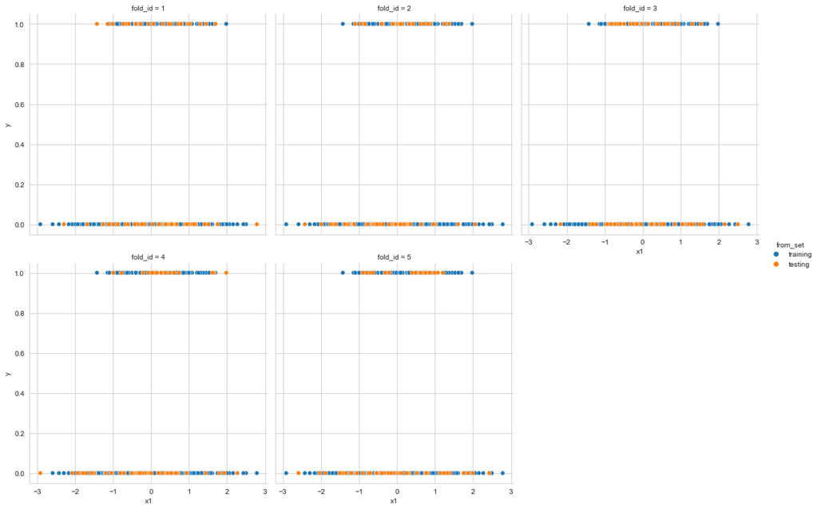

```python
sns.set_style('whitegrid')

sns.relplot(data = all_splits_df, x='x1', y='y', hue='from_set', col='fold_id', col_wrap=3)

plt.show()
```

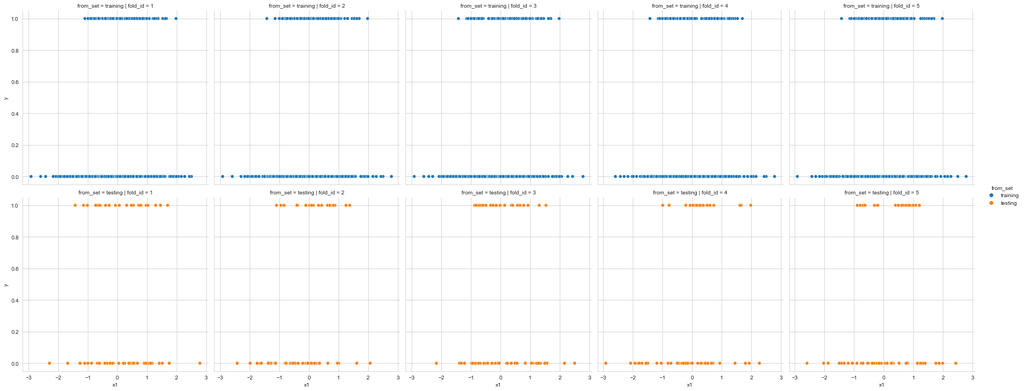

```python
sns.relplot(data = all_splits_df, x='x1', y='y', hue='from_set', col='fold_id', row='from_set')

plt.show()
```

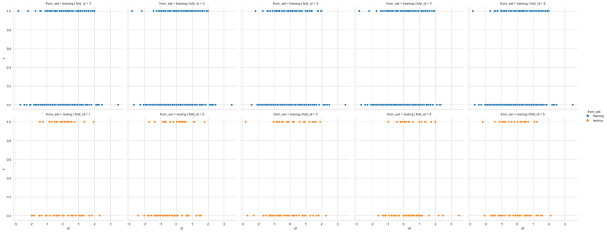

```python
sns.relplot(data = all_splits_df, x='x3', y='y', hue='from_set', col='fold_id', row='from_set')

plt.show()
```

We will train the models using each fold's training set.

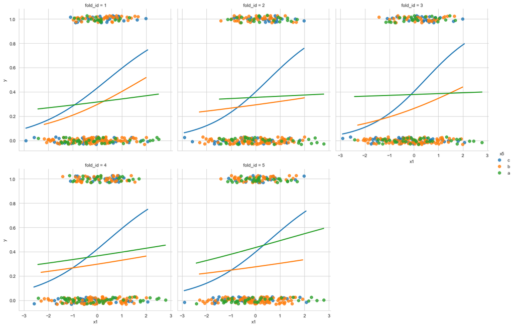

```python
sns.lmplot(data = train_splits_df, x='x1', y='y', hue='x5', col='fold_id', col_wrap=3,
           logistic=True, ci=None, y_jitter=0.03)

plt.show()
```

### Execute cross validation

Define a function which fits on the training set and assess on the test set - but for lecture also assess on the training set so we can compare with the test set performance.

```python
def evaluate_model_with_cv(cv, my_data, my_formula, my_mod):
    y, X = dmatrices(my_formula, data = my_data)

    train_res = []
    test_res = []

    for train_id, test_id in cv.split(X):
        X_train, X_test = X[train_id], X[test_id]
        y_train, y_test = y[train_id], y[test_id]

        mod_fit = my_mod.fit(X_train, y_train.ravel())

        train_res.append( mod_fit.score(X_train, y_train.ravel()) )
        test_res.append( mod_fit.score(X_test, y_test.ravel()) )

    train_df = pd.DataFrame({'Accuracy': train_res})
    train_df['from_set'] = 'training'
    train_df['fold_id'] = train_df.index + 1

    test_df = pd.DataFrame({'Accuracy': test_res})
    test_df['from_set'] = 'testing'
    test_df['fold_id'] = test_df.index + 1

    return pd.concat([train_df, test_df]).reset_index(drop=True)
```

Train and assess all five models with cross-validation.

```python
glm_mle_a = LogisticRegression(penalty='none', solver='lbfgs', max_iter=5001, fit_intercept=True)

glm_mle_b = LogisticRegression(penalty='none', solver='lbfgs', max_iter=5001, fit_intercept=False)
```

```python
cv_results_01 = evaluate_model_with_cv(kf05, df, formula_01 + ' - 1', glm_mle_a)
```

```python
cv_results_01
```

|  | Accuracy | from_set | fold_id |
| --- | --- | --- | --- |
| 0 | 0.637500 | training | 1 |
| 1 | 0.658333 | training | 2 |
| 2 | 0.641667 | training | 3 |
| 3 | 0.633333 | training | 4 |
| 4 | 0.608333 | training | 5 |
| 5 | 0.600000 | testing | 1 |
| 6 | 0.616667 | testing | 2 |
| 7 | 0.600000 | testing | 3 |
| 8 | 0.666667 | testing | 4 |
| 9 | 0.716667 | testing | 5 |

```python
cv_results_04 = evaluate_model_with_cv(kf05, df, formula_04 + ' - 1', glm_mle_b)
```

```python
cv_results_05 = evaluate_model_with_cv(kf05, df, formula_05 + ' - 1', glm_mle_b)
```

```python
cv_results_09 = evaluate_model_with_cv(kf05, df, formula_09 + ' - 1', glm_mle_b)
```

```python
cv_results_10 = evaluate_model_with_cv(kf05, df, formula_10 + ' - 1', glm_mle_b)
```

```python
cv_results_10
```

|  | Accuracy | from_set | fold_id |
| --- | --- | --- | --- |
| 0 | 0.804167 | training | 1 |
| 1 | 0.766667 | training | 2 |
| 2 | 0.804167 | training | 3 |
| 3 | 0.783333 | training | 4 |
| 4 | 0.766667 | training | 5 |
| 5 | 0.583333 | testing | 1 |
| 6 | 0.666667 | testing | 2 |
| 7 | 0.600000 | testing | 3 |
| 8 | 0.683333 | testing | 4 |
| 9 | 0.716667 | testing | 5 |

Assemble all model cross-validation results together.

```python
all_cv_results_list = [cv_results_01, cv_results_04, cv_results_05, cv_results_09, cv_results_10]
```

```python
all_mod_names = ['01', '04', '05', '09', '10']
```

```python
for imod in range(len(all_mod_names)):
    all_cv_results_list[imod]['model'] = all_mod_names[imod]
```

```python
all_cv_results_list[0]
```

|  | Accuracy | from_set | fold_id | model |
| --- | --- | --- | --- | --- |
| 0 | 0.637500 | training | 1 | 01 |
| 1 | 0.658333 | training | 2 | 01 |
| 2 | 0.641667 | training | 3 | 01 |
| 3 | 0.633333 | training | 4 | 01 |
| 4 | 0.608333 | training | 5 | 01 |
| 5 | 0.600000 | testing | 1 | 01 |
| 6 | 0.616667 | testing | 2 | 01 |
| 7 | 0.600000 | testing | 3 | 01 |
| 8 | 0.666667 | testing | 4 | 01 |
| 9 | 0.716667 | testing | 5 | 01 |

```python
all_cv_results_df = pd.concat( all_cv_results_list ).reset_index(drop=True)
```

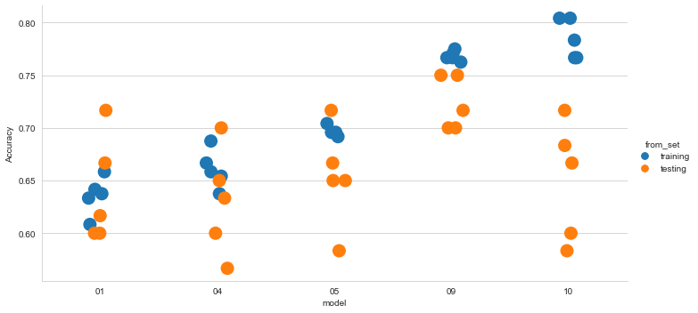

```python
sns.catplot(data = all_cv_results_df, x='model', y='Accuracy', hue='from_set', s=15, aspect=2)

plt.show()
```

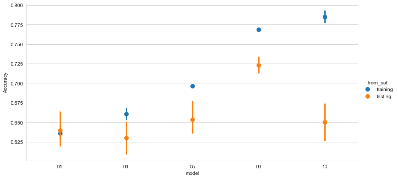

```python
sns.catplot(data = all_cv_results_df, x='model', y='Accuracy', hue='from_set', kind='point', ci=68, join=False, aspect=2)

plt.show()
```

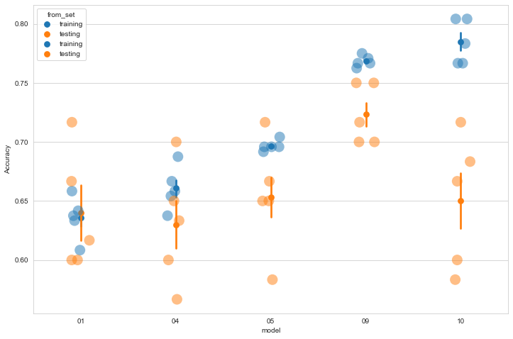

```python
fig, ax = plt.subplots(figsize=(12, 8))

sns.stripplot(data = all_cv_results_df, x='model', y='Accuracy', hue='from_set', s=15, alpha=0.5, ax=ax)

sns.pointplot(data = all_cv_results_df, x='model', y='Accuracy', hue='from_set', join=False, ci=68, ax=ax)

plt.show()
```

## Regularization

### Ridge Penalty or L2-norm

$$Loss + Penalty = C \sum_{n=1}^{N} \bigg(-y_n \log\left(Probability_n\right) - \left(1 - y_n\right) \log\left(1 - Probability_n\right) \bigg) + \frac{1}{2} \sum_{d=0}^{D} \left( \beta_{d}^{2}\right)$$

```python
sk_10_default_c = LogisticRegression(penalty='l2', solver='lbfgs', max_iter=5001, fit_intercept=False, C=1.0).fit(X_10, y_10.ravel())
```

```python
sk_10_large_c = LogisticRegression(penalty='l2', solver='lbfgs', max_iter=5001, fit_intercept=False, C=10000).fit(X_10, y_10.ravel())
```

```python
sk_10_small_c = LogisticRegression(penalty='l2', solver='lbfgs', max_iter=5001, fit_intercept=False, C=0.0001).fit(X_10, y_10.ravel())
```

```python
pd.DataFrame({'statsmodels': fit_10.params,
              'sklearn_mle': list(sk_10_mle.coef_.ravel()),
              'sklearn_large_c': list(sk_10_large_c.coef_.ravel()),
              'sklearn_default_c': list(sk_10_default_c.coef_.ravel()),
              'sklearn_small_c': list(sk_10_small_c.coef_.ravel())},
            index=fit_10.params.index)
```

|  | statsmodels | sklearn_mle | sklearn_large_c | sklearn_default_c | sklearn_small_c |
| --- | --- | --- | --- | --- | --- |
| Intercept | 0.745848 | 0.745668 | 0.745550 | 0.433713 | -0.000895 |
| x5[T.b] | -1.130891 | -0.385047 | -0.385085 | -0.338735 | -0.003048 |
| x5[T.c] | 0.457841 | 1.203648 | 1.204070 | 0.810038 | -0.000588 |
| np.power(x1, 2) | -1.074338 | -1.074234 | -1.074137 | -0.810828 | -0.008452 |
| x5[T.b]:np.power(x1, 2) | 0.402314 | 0.402282 | 0.402104 | 0.173079 | -0.003862 |
| x5[T.c]:np.power(x1, 2) | -0.509309 | -0.509662 | -0.510029 | -0.282306 | -0.001864 |
| np.power(x2, 2) | -0.835012 | -0.835028 | -0.835053 | -0.586107 | -0.007527 |
| x5[T.b]:np.power(x2, 2) | -0.110747 | -0.110721 | -0.110683 | -0.231738 | -0.004516 |
| x5[T.c]:np.power(x2, 2) | 0.060637 | 0.060735 | 0.060621 | -0.085639 | -0.001907 |
| np.power(x3, 2) | -0.271307 | -0.271293 | -0.271302 | -0.188621 | -0.006391 |
| x5[T.b]:np.power(x3, 2) | 0.284589 | 0.284556 | 0.284634 | 0.198223 | -0.002633 |
| x5[T.c]:np.power(x3, 2) | -0.031187 | -0.031358 | -0.031412 | 0.023083 | -0.000926 |
| np.power(x4, 2) | 0.180032 | 0.180082 | 0.180146 | 0.194123 | -0.003247 |
| x5[T.b]:np.power(x4, 2) | -0.000157 | -0.000202 | -0.000284 | -0.028338 | -0.002488 |
| x5[T.c]:np.power(x4, 2) | -0.246957 | -0.246894 | -0.247121 | -0.238705 | -0.001019 |
| x1 | 0.550972 | 0.550777 | 0.550492 | 0.507425 | 0.002058 |
| x5[T.b]:x1 | 0.357494 | 0.357599 | 0.358034 | 0.235042 | 0.000719 |
| x5[T.c]:x1 | 0.401011 | 0.401345 | 0.401593 | 0.298681 | 0.001181 |
| x2 | -1.344587 | -1.344532 | -1.344545 | -1.071252 | -0.003636 |
| x5[T.b]:x2 | -0.039016 | -0.039029 | -0.039082 | -0.123611 | -0.001446 |
| x5[T.c]:x2 | 0.091459 | 0.091337 | 0.091357 | -0.098983 | -0.001490 |
| x3 | -0.074242 | -0.074240 | -0.074501 | -0.004361 | 0.001104 |
| x5[T.b]:x3 | 0.980051 | 0.980028 | 0.980323 | 0.765847 | 0.001377 |
| x5[T.c]:x3 | -0.348263 | -0.348396 | -0.347938 | -0.317579 | -0.000032 |
| x4 | -0.207680 | -0.207508 | -0.207402 | -0.123763 | -0.000189 |
| x5[T.b]:x4 | 0.308241 | 0.308017 | 0.307980 | 0.173946 | -0.000387 |
| x5[T.c]:x4 | 0.375129 | 0.375018 | 0.374627 | 0.223986 | 0.000277 |
| x1:x2 | -0.636838 | -0.637185 | -0.637382 | -0.219265 | -0.000405 |
| x5[T.b]:x1:x2 | 1.589596 | 1.589852 | 1.590159 | 0.956608 | 0.000271 |
| x5[T.c]:x1:x2 | -0.841923 | -0.841631 | -0.841971 | -0.712795 | -0.000377 |
| x1:x3 | -0.227950 | -0.228125 | -0.228510 | -0.082761 | -0.000149 |
| x5[T.b]:x1:x3 | -0.076753 | -0.076567 | -0.076042 | -0.130761 | 0.000105 |
| x5[T.c]:x1:x3 | 1.099760 | 1.100243 | 1.100815 | 0.604196 | 0.000053 |
| x1:x4 | 0.267787 | 0.267579 | 0.267464 | 0.168509 | -0.000139 |
| x5[T.b]:x1:x4 | -0.768738 | -0.768438 | -0.768434 | -0.595294 | -0.000403 |
| x5[T.c]:x1:x4 | 0.534197 | 0.534747 | 0.535069 | 0.256380 | -0.000061 |
| x2:x3 | -0.321506 | -0.321794 | -0.321851 | 0.020130 | 0.001336 |
| x5[T.b]:x2:x3 | 1.037686 | 1.038000 | 1.037965 | 0.548286 | 0.001152 |
| x5[T.c]:x2:x3 | 0.338556 | 0.338824 | 0.339116 | -0.108071 | -0.000308 |
| x2:x4 | -0.153466 | -0.153259 | -0.153017 | -0.133202 | -0.000191 |
| x5[T.b]:x2:x4 | 0.307197 | 0.306935 | 0.306732 | 0.215776 | -0.000268 |
| x5[T.c]:x2:x4 | -0.120883 | -0.120948 | -0.121558 | -0.073159 | -0.000010 |
| x3:x4 | 0.098378 | 0.098592 | 0.098761 | 0.115182 | 0.001509 |
| x5[T.b]:x3:x4 | -0.206761 | -0.206986 | -0.207079 | -0.168834 | -0.000095 |
| x5[T.c]:x3:x4 | 0.069240 | 0.068941 | 0.068456 | 0.110550 | 0.000885 |

Use built in functions from sklearn to assess performance with cross-validation.

```python
from sklearn.model_selection import cross_val_score
```

```python
ridge_default_c = LogisticRegression(penalty='l2', solver='lbfgs', C=1.0, max_iter=5001, fit_intercept=False)

ridge_large_c = LogisticRegression(penalty='l2', solver='lbfgs', C=10000, max_iter=5001, fit_intercept=False)

ridge_small_c = LogisticRegression(penalty='l2', solver='lbfgs', C=0.0001, max_iter=5001, fit_intercept=False)
```

```python
test_accuracy_ridge_default_c = cross_val_score( ridge_default_c, X_10, y_10.ravel(), cv=kf05)
```

```python
test_accuracy_ridge_default_c
```

```
array([0.6       , 0.66666667, 0.66666667, 0.71666667, 0.71666667])
```

```python
test_accuracy_ridge_large_c = cross_val_score( ridge_large_c, X_10, y_10.ravel(), cv=kf05)
```

```python
test_accuracy_ridge_small_c = cross_val_score( ridge_small_c, X_10, y_10.ravel(), cv=kf05)
```

```python
print( test_accuracy_ridge_large_c.mean() )

print( test_accuracy_ridge_default_c.mean() )

print( test_accuracy_ridge_small_c.mean() )
```

```
0.65
0.6733333333333333
0.6599999999999999
```

### Find optimal C value

Use built in functions dedicated to *tuning* the `C` parameter with cross-validation.

```python
from sklearn.linear_model import LogisticRegressionCV
```

```python
ridge_tune_results = LogisticRegressionCV(penalty='l2', Cs=101, cv=kf05, solver='lbfgs', max_iter=5001, fit_intercept=False).\
fit(X_10, y_10.ravel())
```

```python
dir( ridge_tune_results )
```

[output not shown]

[output cut: 21 more lines]

```
 'n_jobs',
 'penalty',
 'predict',
 'predict_log_proba',
 'predict_proba',
 'random_state',
 'refit',
 'score',
 'scores_',
 'scoring',
 'set_params',
 'solver',
 'sparsify',
 'tol',
 'verbose']
```

Optimal value of `C`:

```python
ridge_tune_results.C_
```

```
array([0.02511886])
```

```python
ridge_tune_results.score
```

```
<bound method LogisticRegressionCV.score of LogisticRegressionCV(Cs=101,
                     cv=KFold(n_splits=5, random_state=101, shuffle=True),
                     fit_intercept=False, max_iter=5001)>
```

```python
type( ridge_tune_results.scores_ )
```

```
dict
```

```python
ridge_tune_results.scores_.keys()
```

```
dict_keys([1.0])
```

```python
ridge_tune_results.scores_[1.0].shape
```

```
(5, 101)
```

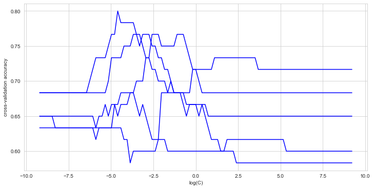

```python
fig, ax = plt.subplots(figsize=(12, 6))

ax.plot(np.log(ridge_tune_results.Cs_), ridge_tune_results.scores_[1.0].T, 'b-')
ax.set_xlabel('log(C)')
ax.set_ylabel("cross-validation accuracy")

plt.show()
```

Average the accuracy across the folds for each value of C.

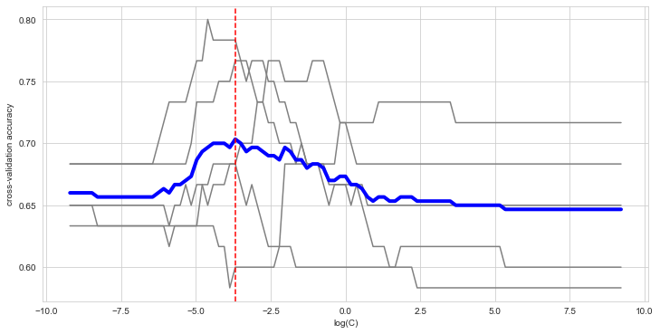

```python
fig, ax = plt.subplots(figsize=(12, 6))

ax.plot(np.log(ridge_tune_results.Cs_), ridge_tune_results.scores_[1.0].T, color='grey')
ax.plot(np.log(ridge_tune_results.Cs_), ridge_tune_results.scores_[1.0].mean(axis=0), color='blue', linewidth=4)
ax.axvline(x=np.log(ridge_tune_results.C_), color='red', linestyle='dashed')
ax.set_xlabel('log(C)')
ax.set_ylabel("cross-validation accuracy")

plt.show()
```

### Lasso or L1-norm

$$Loss + Penalty = C \sum_{n=1}^{N} \bigg(-y_n \log\left(Probability_n\right) - \left(1 - y_n\right) \log\left(1 - Probability_n\right) \bigg) + \frac{1}{2} \sum_{d=0}^{D} \left| \beta_{d}\right|$$

```python
lasso_tune_results = LogisticRegressionCV(penalty='l1', Cs=101, cv=kf05, solver='saga', max_iter=5001, fit_intercept=False).\
fit(X_10, y_10.ravel())
```

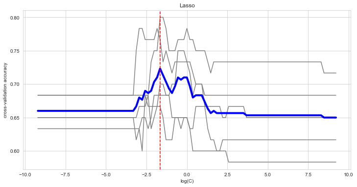

```python
fig, ax = plt.subplots(figsize=(12, 6))

ax.plot(np.log(lasso_tune_results.Cs_), lasso_tune_results.scores_[1.0].T, color='grey')
ax.plot(np.log(lasso_tune_results.Cs_), lasso_tune_results.scores_[1.0].mean(axis=0), color='blue', linewidth=4)
ax.axvline(x=np.log(lasso_tune_results.C_), color='red', linestyle='dashed')
ax.set_xlabel('log(C)')
ax.set_ylabel("cross-validation accuracy")
ax.set_title("Lasso")

plt.show()
```

Compare the coefficents between ridge and lasso penalties.

```python
print( ridge_tune_results.coef_)
```

```
[[ 0.0026995  -0.11931797  0.06902265 -0.31627505 -0.10564409 -0.04049111
  -0.2233893  -0.14438223 -0.04843695 -0.11430762  0.00229154  0.03007259
   0.08752096 -0.01641242 -0.03632984  0.19426107  0.03908438  0.11803916
  -0.35927671 -0.0916124  -0.13676662  0.06973713  0.15938447 -0.04001542
  -0.00084202 -0.02253737  0.04022057 -0.04063927  0.10926847 -0.10777458
  -0.00509602 -0.00992036  0.05783573 -0.01138201 -0.11690377  0.03867204
   0.05822889  0.08475377 -0.05481607 -0.01809156 -0.00582872 -0.00978624
   0.0880902  -0.02946137  0.06886088]]
```

```python
print( lasso_tune_results.coef_ )
```

```
[[ 0.         -0.05098944  0.         -0.48015831  0.          0.
  -0.33365698 -0.16829243  0.         -0.07613669  0.          0.
   0.08205954  0.          0.          0.35643412  0.          0.
  -0.72812438  0.          0.          0.          0.28016463  0.
   0.          0.          0.          0.          0.12055881 -0.03172708
   0.          0.          0.          0.         -0.15815802  0.
   0.          0.05762393  0.          0.          0.          0.
   0.06756567  0.          0.        ]]
```

```python
pd.DataFrame({'statsmodels': fit_10.params,
              'sklearn_mle': list(sk_10_mle.coef_.ravel()),
              'ridge_best': list(ridge_tune_results.coef_.ravel()),
              'lasso_best': list(lasso_tune_results.coef_.ravel())},
            index=fit_10.params.index)
```

|  | statsmodels | sklearn_mle | ridge_best | lasso_best |
| --- | --- | --- | --- | --- |
| Intercept | 0.745848 | 0.745668 | 0.002699 | 0.000000 |
| x5[T.b] | -1.130891 | -0.385047 | -0.119318 | -0.050989 |
| x5[T.c] | 0.457841 | 1.203648 | 0.069023 | 0.000000 |
| np.power(x1, 2) | -1.074338 | -1.074234 | -0.316275 | -0.480158 |
| x5[T.b]:np.power(x1, 2) | 0.402314 | 0.402282 | -0.105644 | 0.000000 |
| x5[T.c]:np.power(x1, 2) | -0.509309 | -0.509662 | -0.040491 | 0.000000 |
| np.power(x2, 2) | -0.835012 | -0.835028 | -0.223389 | -0.333657 |
| x5[T.b]:np.power(x2, 2) | -0.110747 | -0.110721 | -0.144382 | -0.168292 |
| x5[T.c]:np.power(x2, 2) | 0.060637 | 0.060735 | -0.048437 | 0.000000 |
| np.power(x3, 2) | -0.271307 | -0.271293 | -0.114308 | -0.076137 |
| x5[T.b]:np.power(x3, 2) | 0.284589 | 0.284556 | 0.002292 | 0.000000 |
| x5[T.c]:np.power(x3, 2) | -0.031187 | -0.031358 | 0.030073 | 0.000000 |
| np.power(x4, 2) | 0.180032 | 0.180082 | 0.087521 | 0.082060 |
| x5[T.b]:np.power(x4, 2) | -0.000157 | -0.000202 | -0.016412 | 0.000000 |
| x5[T.c]:np.power(x4, 2) | -0.246957 | -0.246894 | -0.036330 | 0.000000 |
| x1 | 0.550972 | 0.550777 | 0.194261 | 0.356434 |
| x5[T.b]:x1 | 0.357494 | 0.357599 | 0.039084 | 0.000000 |
| x5[T.c]:x1 | 0.401011 | 0.401345 | 0.118039 | 0.000000 |
| x2 | -1.344587 | -1.344532 | -0.359277 | -0.728124 |
| x5[T.b]:x2 | -0.039016 | -0.039029 | -0.091612 | 0.000000 |
| x5[T.c]:x2 | 0.091459 | 0.091337 | -0.136767 | 0.000000 |
| x3 | -0.074242 | -0.074240 | 0.069737 | 0.000000 |
| x5[T.b]:x3 | 0.980051 | 0.980028 | 0.159384 | 0.280165 |
| x5[T.c]:x3 | -0.348263 | -0.348396 | -0.040015 | 0.000000 |
| x4 | -0.207680 | -0.207508 | -0.000842 | 0.000000 |
| x5[T.b]:x4 | 0.308241 | 0.308017 | -0.022537 | 0.000000 |
| x5[T.c]:x4 | 0.375129 | 0.375018 | 0.040221 | 0.000000 |
| x1:x2 | -0.636838 | -0.637185 | -0.040639 | 0.000000 |
| x5[T.b]:x1:x2 | 1.589596 | 1.589852 | 0.109268 | 0.120559 |
| x5[T.c]:x1:x2 | -0.841923 | -0.841631 | -0.107775 | -0.031727 |
| x1:x3 | -0.227950 | -0.228125 | -0.005096 | 0.000000 |
| x5[T.b]:x1:x3 | -0.076753 | -0.076567 | -0.009920 | 0.000000 |
| x5[T.c]:x1:x3 | 1.099760 | 1.100243 | 0.057836 | 0.000000 |
| x1:x4 | 0.267787 | 0.267579 | -0.011382 | 0.000000 |
| x5[T.b]:x1:x4 | -0.768738 | -0.768438 | -0.116904 | -0.158158 |
| x5[T.c]:x1:x4 | 0.534197 | 0.534747 | 0.038672 | 0.000000 |
| x2:x3 | -0.321506 | -0.321794 | 0.058229 | 0.000000 |
| x5[T.b]:x2:x3 | 1.037686 | 1.038000 | 0.084754 | 0.057624 |
| x5[T.c]:x2:x3 | 0.338556 | 0.338824 | -0.054816 | 0.000000 |
| x2:x4 | -0.153466 | -0.153259 | -0.018092 | 0.000000 |
| x5[T.b]:x2:x4 | 0.307197 | 0.306935 | -0.005829 | 0.000000 |
| x5[T.c]:x2:x4 | -0.120883 | -0.120948 | -0.009786 | 0.000000 |
| x3:x4 | 0.098378 | 0.098592 | 0.088090 | 0.067566 |
| x5[T.b]:x3:x4 | -0.206761 | -0.206986 | -0.029461 | 0.000000 |
| x5[T.c]:x3:x4 | 0.069240 | 0.068941 | 0.068861 | 0.000000 |

In truth we need stratified Kfold.

```python
from sklearn.model_selection import StratifiedKFold
```

```python
k05_stratify = StratifiedKFold(n_splits=5, shuffle=True, random_state=101)
```

Repeated cross-validation.

```python
from sklearn.model_selection import RepeatedStratifiedKFold
```